# NEO-SMART Engine: knowledge base

NSF Regional Innovation Engines, Cohort 2. Technology profile v1. Draft, in progress

**NSF NEO-SMART Engine in Northeast Ohio**, led by Case Western Reserve University. NSF award 2532460, start August 2026. Search window for papers and patents: from August 2021 (five years before the award) onward.

## At a glance

| Measure | Value |
| --- | --- |
| People named by NSF or the Engine’s site | 10 |
| of them active researchers (>= 5 works since window start) | 0 |
| Team members who are inventors (2021-2025 grants, in the region) | 0 |
| Partners (site list + team members’ organisations) | 76 |
| Knowledge-producer partners (universities, labs, institutes) | 12 |
| Partner papers in the Engine’s topics | 1342 |
| of them with an in-region partner | 449 |
| Regional patents in the technology profile (2021-2025 grants) | 402 |
| Location quotient of the technology profile (patents) | 3.29 |
| Share of regional technology patents owned by partners | 20.4% |

## Economic base

| NAICS | Industry | Employment in region | Establishments | Share of US employment | Employment LQ |
| --- | --- | --- | --- | --- | --- |
| 325 | Chemical manufacturing | 19,151 | 323 | 2.1% | 1.67 |
| 3255 | Paint, coating, and adhesive manufacturing | 3,683 | 49 | 4.7% | 3.76 |
| 326 | Plastics and rubber products manufacturing | 28,083 | 401 | 3.4% | 2.74 |
| 331 | Primary metal manufacturing | 18,643 | 186 | 5.2% | 4.18 |
| 332 | Fabricated metal product manufacturing | 47,221 | 1,610 | 3.3% | 2.61 |

Industries related to the Engine’s technology (chosen from the NSF abstract, see `data/manual/engine_naics.csv`). County Business Patterns 2023; LQ = the industry’s share of regional employment relative to its share of US employment (1 = US average). Region: 18 of 18.

## Technology profile

Version 1. The profile has 5 statements. Item 1 comes from the grant title, the rest from the technical part of the NSF abstract. Each statement is mapped to one OpenAlex topic and to CPC codes.

| # | Source | Statement | OpenAlex topic | Subfield | CPC |
| --- | --- | --- | --- | --- | --- |
| 1 | title | Advanced materials manufacturing technology | Diverse Industrial Engineering Technologies | Industrial and Manufacturing Engineering | NA |
| 2 | abstract | Metals production, processing, recovery and recycling | Extraction and Separation Processes | Metals and Alloys | C22B; C22C |
| 3 | abstract | Polymers: feedstock development, processing, reprocessing and recycling of plastics | Polymer crystallization and properties | Polymers and Plastics | C08J; B29B17 |
| 4 | abstract | Chemicals and coatings: development and durability of industrial coatings | Corrosion Behavior and Inhibition | Materials Chemistry | C09D; C23F |
| 5 | abstract | AI/ML and computational methods that accelerate materials design | Machine Learning in Materials Science | Materials Chemistry | G16C60 |

## People

| Role | People |
| --- | --- |
| organizer | 7 |
| research_admin | 2 |
| corporate_rd | 1 |

| Name | Role | On NSF award | Title | Organisation | Works since window (in Engine topics) | h-index | Patents 2021-25 (in Engine profile) | Site | OpenAlex |
| --- | --- | --- | --- | --- | --- | --- | --- | --- | --- |
| Michael Oakes | research_admin |  | Executive Vice President for Research | Case Western Reserve University | - | - |  | [page](https://neosmartengine.org/about/) |  |
| Nigamanth Sridhar | research_admin |  | Executive Vice President & Provost | Cleveland State University | 2 (0) | 13 |  | [page](https://neosmartengine.org/about/) | [profile](https://openalex.org/A5041569881) |
| Julie Edgar | corporate_rd |  | Chief Technology Officer | The Lubrizol Corporation | 0 | 4 |  | [page](https://neosmartengine.org/about/) | [profile](https://openalex.org/A5040514198) |
| Baiju Shah | organizer | Co-PI | President & CEO | Greater Cleveland Partnership | - | - |  | [page](https://neosmartengine.org/about/) |  |
| Bethia Burke | organizer | Co-PI | President | Fund for Our Economic Future | - | - |  | [page](https://neosmartengine.org/about/) |  |
| Catherine Tkachyk | organizer |  | Chief Operating Officer (Interim) | NEO-SMART | - | - |  | [page](https://neosmartengine.org/about/) |  |
| Marcia Ballinger | organizer | Co-PI | President | Lorain County Community College | - | - |  | [page](https://neosmartengine.org/about/) |  |
| Matt Dolan | organizer | Co-PI | CEO | Team NEO | - | - |  | [page](https://neosmartengine.org/about/) |  |
| Nick Barendt | organizer | PI | Chief Executive Officer and Principal Investigator; Gover… | NEO-SMART | 0 | 6 |  | [page](https://neosmartengine.org/about/) | [profile](https://openalex.org/A5007924702) |
| Steve Millard | organizer |  | President & CEO | Greater Akron Chamber | - | - |  | [page](https://neosmartengine.org/about/) |  |

Publication counts are shown only where the OpenAlex author matches both the name and the person’s current organisation. The OpenAlex link is given only for these reliable matches, and not for profiles flagged as possibly merging several namesakes. *Site* links to the page of the Engine’s website where the person is named. Click a number of works to see the list on the Publications page. *Patents*: US grants 2021-2025 with the person among the inventors (same last and first name, address in the Engine’s states); click the number for the list on the Patents page. In brackets: works in the Engine’s topics, patents with a CPC code in the Engine’s technology profile.

## Researchers at partner organisations

| # | Researcher | Partner | Works in the Engine’s topics | Citations | Years | Most cited of these works |
| --- | --- | --- | --- | --- | --- | --- |
| 1 | [David M. Bastidas](https://openalex.org/A5005429869) | University of Akron | 21 | 324 | 2021-2026 | [Effect of Molecular Structure on the B3LYP-Computed HOMO–…](https://openalex.org/W4406388663) |
| 2 | [Ica Manas‐Zloczower](https://openalex.org/A5020724814) | Case Western Reserve University | 17 | 228 | 2022-2026 | [Vitrimerization of rigid thermoset polyurethane foams: A …](https://openalex.org/W4291378410) |
| 3 | [Gary E. Wnek](https://openalex.org/A5046423105) | Case Western Reserve University | 15 | 84 | 2022-2026 | [Poly(hydroxyalkanoates): Emerging Biopolymers in Biomedic…](https://openalex.org/W4392637545) |
| 4 | [Rohan N. Akolkar](https://openalex.org/A5013794190) | Case Western Reserve University | 15 | 74 | 2022-2026 | [Sustainable and Energy-Efficient Production of Rare-Earth…](https://openalex.org/W4392192271) |
| 5 | [Roger H. French](https://openalex.org/A5085904418) | Case Western Reserve University | 14 | 137 | 2023-2026 | [Materials Data Science Ontology(MDS-Onto): Unifying Domai…](https://openalex.org/W4409444586) |
| 6 | [Huichun Judy Zhang](https://openalex.org/A5085548566) | Case Western Reserve University | 13 | 1394 | 2021-2026 | [Machine Learning: New Ideas and Tools in Environmental Sc…](https://openalex.org/W3193638860) |
| 7 | [Christine E. Duval](https://openalex.org/A5061453332) | Case Western Reserve University | 13 | 141 | 2022-2026 | [Investigation of Rare Earth Element Binding to a Surface-…](https://openalex.org/W4393165026) |
| 8 | [Shi‐Qing Wang](https://openalex.org/A5100636057) | University of Akron | 13 | 138 | 2021-2026 | [Fracture Behavior of Polymers in Plastic and Elastomeric …](https://openalex.org/W4396596369) |
| 9 | [Junpeng Wang](https://openalex.org/A5002963148) | University of Akron | 12 | 368 | 2023-2026 | [Mechanochemical Degradation and Recycling of Synthetic Po…](https://openalex.org/W4362457734) |
| 10 | [João Manuel Maia](https://openalex.org/A5058571119) | Case Western Reserve University | 12 | 54 | 2021-2026 | [Robust prediction of frictional contact network in near-j…](https://openalex.org/W4412006724) |
| 11 | [Ulises Martin](https://openalex.org/A5078114526) | University of Akron | 10 | 170 | 2021-2024 | [Corrosion Inhibition Mechanism of Steel Reinforcements in…](https://openalex.org/W3207729797) |
| 12 | [Toshikazu Miyoshi](https://openalex.org/A5008605509) | University of Akron | 10 | 85 | 2022-2026 | [Polymer Chains Fold Prior to Crystallization](https://openalex.org/W4210847966) |
| 13 | [Nicholas Scott Sinclair](https://openalex.org/A5044976825) | Case Western Reserve University | 10 | 56 | 2023-2026 | [Sustainable and Energy-Efficient Production of Rare-Earth…](https://openalex.org/W4392192271) |
| 14 | [Joshua Stuckner](https://openalex.org/A5072682834) | NASA Glenn Research Center | 10 | 32 | 2021-2026 | [Optimal experimental design with fast neural network surr…](https://openalex.org/W3194300689) |
| 15 | [Chris Yingchun Yuan](https://openalex.org/A5024601679) | Case Western Reserve University | 9 | 227 | 2022-2025 | [Sustainable battery manufacturing in the future](https://openalex.org/W4387527090) |

The grant names mostly managers; the technology is often developed at the partner universities and labs. These are the authors with the most works in the Engine’s OpenAlex topics written at a knowledge-producer partner in the Engine’s states, since the window start (at least 3 works; top 15). The list depends on the technology profile version. OpenAlex sometimes merges namesakes into one author: check the profile before relying on a name.

## Partners

| Organisation class | Partners |
| --- | --- |
| company | 29 |
| intermediary | 21 |
| government | 6 |
| university | 6 |
| community_college | 4 |
| research_institute | 4 |
| investor | 2 |
| national_lab | 2 |
| philanthropy | 2 |

Partner list on the site: *Complete (74 organisations)*.

| Partner | Class | State | OpenAlex works since window (all topics) |
| --- | --- | --- | --- |
| Case Western Reserve University | university | Ohio | 41410 |
| Argonne National Laboratory | national_lab | Illinois | 28153 |
| Kent State University | university |  | 8881 |
| RTI International | research_institute | North Carolina | 5846 |
| University of Akron | university | Ohio | 4049 |
| Cleveland State University | university | Ohio | 4006 |
| NASA Glenn Research Center | national_lab | Ohio | 1974 |
| Youngstown State University | university | Ohio | 1048 |
| Walsh University | university | Ohio | 123 |
| ReMADE Institute | research_institute | New York | 4 |
| NSF HAMMER-ERC | research_institute |  | NA |
| NSF TARDISS-ERC | research_institute |  | NA |

## Science base: partner papers in the Engine’s topics

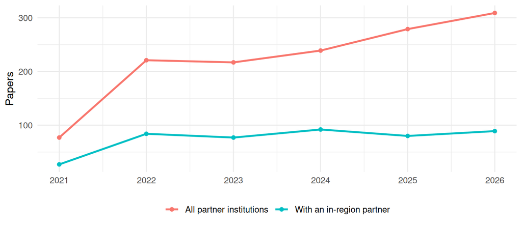

| Partner | Papers in topics |
| --- | --- |
| Argonne National Laboratory | 884 |
| Case Western Reserve University | 214 |
| University of Akron | 169 |
| NASA Glenn Research Center | 45 |
| Cleveland State University | 20 |
| Kent State University | 13 |
| Youngstown State University | 8 |
| Walsh University | 4 |
| ReMADE Institute | 2 |
| RTI International | 1 |

## Technology base: patents

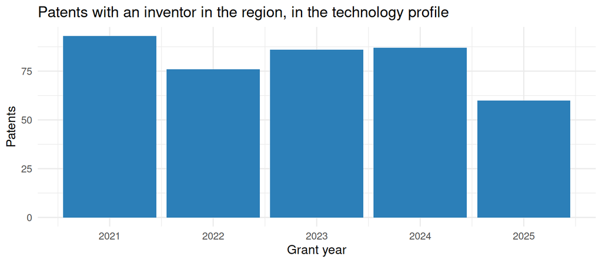

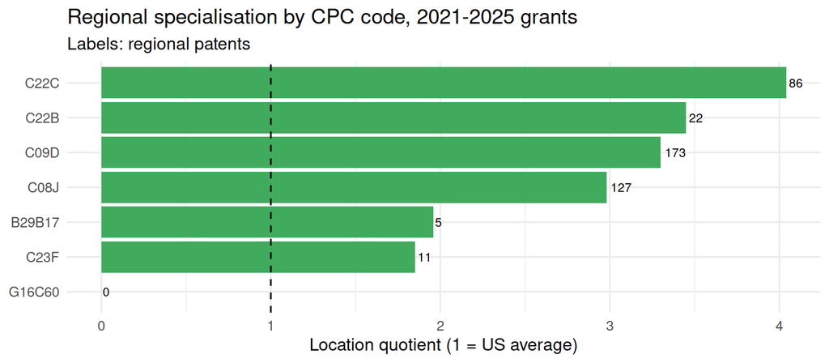

| Assignee | Regional patents in profile |
| --- | --- |
| SWIMC LLC | 29 |
| PROMERUS, LLC | 22 |
| Bridgestone Americas Tire Operations, LLC | 13 |
| POWDERMET, INC. | 12 |
| PPG Industries Ohio, Inc. | 12 |
| THE UNIVERSITY OF AKRON | 12 |
| Case Western Reserve University | 9 |
| Molten Metal Equipment Innovations, LLC | 9 |
| Terves, LLC | 9 |
| The Sherwin-Williams Company | 9 |

Partner-owned patents invented in the region: 1728, of which 82 (4.7%) fall in the Engine’s technology profile.

## Competition

With 402 patents in the technology profile (2021-2025 grants), the Engine’s region would rank **12** among US states; its specialisation (LQ) is 3.287.

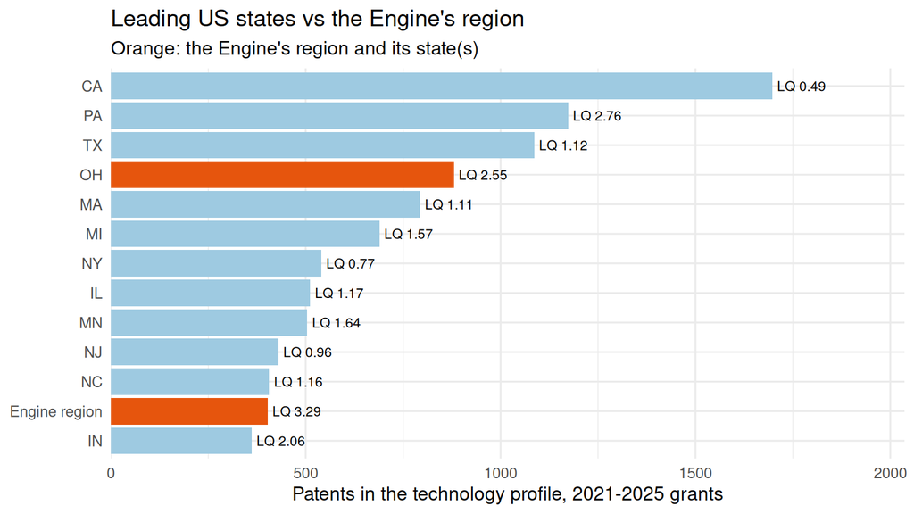

| Country | Share of US patents in profile | Share of world papers in topics |
| --- | --- | --- |
| US | 34.5% | 10.6% |
| JP | 28.7% | 3.2% |
| KR | 8.6% | 2.5% |
| CN | 7.3% | 25.1% |
| DE | 6.5% | 3.7% |
| FR | 3.5% | 2.4% |
| CA | 2.4% | 1.8% |
| GB | 2.0% | 2.9% |
| TW | 1.8% | NA |
| BE | 1.6% | NA |

Patents: inventor countries on US grants in the profile (a patent counts for every country of its inventors). Papers: author countries of OpenAlex works in the Engine’s topics since the window start.

## Data and limitations

- People: PIs and Co-PIs from the NSF Award API; leadership listed on the Engine’s website. Roles come from titles and organisations, revised with OpenAlex evidence.
- Partners: as listed on the Engine’s website, plus organisations of team members. Some Engines publish partner logos without names.
- Region: the Engine’s counties where the list is known (NEO-SMART: 18 Northeast Ohio counties; STELLAR: 11 counties from the NSF abstract), otherwise its states (state-level proxy).
- Technology profile: v1 (switch versions in the header). Partner papers and regional patents depend on it: v1 uses mostly CPC subclasses, the v3.1 core uses CPC main groups, which are narrower, so it counts fewer patents and the LQ of a small region rests on few patents.
- Papers: OpenAlex; partner papers are restricted to the Engine’s OpenAlex topics.
- Patents: USPTO grants 2021-2025; inventor locations from PatentsView; pre-grant publications are not included.